# Python `plotly` kütüphanesi ile interaktif grafik hazırlama

`plotly` interaktif grafikler hazırlayabileceğiniz bir python paketidir. Resmi sayfalarında kendilerini *"Plotly provides a web-service for hosting graphs!"* şeklinde tanımlıyorlar. Yani hazırladığınız grafikleri `plotly` sunucularında insanlara açabilirsiniz.

Tabi işin bir de "open source" boyutu var. Biz bu yazımızda `plotly` paketinin "open source" kısmını kullanarak interaktif grafikleri nasıl yapabileceğimizi inceleyeceğiz.

[figure not shown]

Ref: https://plot.ly/python/

## Kurulum ve kontroller

Kurulum için `plotly`nin internet sitesindeki yönergeleri izlemenizi tavsiye ederim.

https://plot.ly/python/getting-started/

Kurulumu **pip** kullanarak kolaylıkla yapabilirsiniz.

`$ pip install plotly`

```python
import plotly
%matplotlib notebook
# ilk önce versiyon kontrolü yapalım
plotly.__version__
```

```
'3.9.0'
```

```python
# Bu kısım plotly'nin offline olarak çalışabilmesi için gerekli
import plotly.graph_objs as go
from plotly.offline import download_plotlyjs, init_notebook_mode, plot, iplot
```

```python
# yine offline çalışabilmesi için
# her notebook başlangıcında bunu çağırmamız gerekiyor
init_notebook_mode(connected=True)
```

Kontrol amacıyla ilk grafiğimizi çizdirelim

```python
# ilk grafiğimizi çizdirelim
iplot([{"x": [1, 2, 3], "y": [3, 1, 6]}])
```

[interactive chart not shown]

Grafiğin üzerine fare imleci ile geldiğinizde veri noktalarını görebiliyor olmanız lazım :) İlerleyen bölümlerde örnekler üzerinden giderek bu paketi daha yakından tanımaya çalışacağız.

## Birkaç temel çizim

### `scatter plot` (saçılım grafiği)

Eğer elinizde iki değişken varsa bunların arasındaki ilişkiyi görebileceğiniz en temel grafik `scatter plot`tır. Şimdi bunu `plotly` ile nasıl çizebiliriz bir bakalım.

Bu amaçla `plotly`nin sitesindeki örnek üzerinden gidip bu grafiği geliştirmeye çalışacağım.

```python
# grafik objelerini de go şeklinde import edelim
import plotly.graph_objs as go
from plotly.offline import download_plotlyjs, init_notebook_mode, plot, iplot
```

`plotly` kütüphanesinde çizdirdiğimiz her grafik bir obje olarak ele alınıyor. Bu sebeple `import plotly.graph_objs as go` kalıbı önemli. Örnek yaptıkça daha rahat anlayacağımızı düşünüyorum :)

```python
# numpy kütüphanesi de import edelim.
import numpy as np
```

`numpy` en çok kullandığımız kütüphanelerden biri. `numpy` kütüphanesini nümerik ve matematik işlem yapmak için kullanıyoruz. Konu ile ilgili ayrıntılı bilgi almak istiyorsanız sitemizde yeterli materyal mevcut :)

https://www.datafloyd.com/tr/pyhton-numpy-kutuphanesinin-kullanimi/

```python
# Rasgele 1000 nokta yaratalım
N = 1000
# Aynı sonuçları yaratabilmek için bu sayıyı kullanalım
random_seed = 42
np.random.seed(random_seed)
```

```python
# numpy kütüphanesindeki random modülünü kullanıyoruz
# x ekseni için ayrı değerler
random_x = np.random.randn(N)
# y ekseni için ayrı değerler
random_y = np.random.randn(N)
```

İsterseniz öncelikle `matplotlib` kütüphanesi ile nasıl göründüğüne bakalım.

```python
import matplotlib.pyplot as plt
plt.plot(random_x,random_y,'.')
plt.show()
```

[output not shown]

Not: `matplotlib` python'un görselleştirme için kullanılan artık standart hale gelmiş bir kütüphanesidir. Bilgi almak için aşağıdaki bağlantıları kullanabilirsiniz:

https://www.datafloyd.com/tr/pyhton-matplotlib-kutuphanesini-kullanarak-veri-gorsellestirme-temel-grafikler%C2%B6/

https://www.datafloyd.com/tr/matplotlib-ile-ileri-seviye-gorsellestirme/

```python
# Plotly'de veriyi çizdirebilmek için trace denen bir format oluşturuyoruz.
# bunu yaparken de yukarıdaki grafik obje kütüphanesini kullanıyoruz.
trace = go.Scatter(
    x = random_x,
    y = random_y,


    # Sadece scatter içeren bir grafik çizdirmek için bu parametreyi markers
    # olarak ayarlamamız lazım
    mode = 'markers'
)
# trace kısmını list şeklinde girdi sağlamamız gerekiyor
# aksi halde hata alırız.
iplot([trace])
```

[interactive chart not shown]

Bu `go.Scatter` sınıfı ile neler yapabildiğimizi görmek için `help` komutu ile yardım alalım.

```python
# help(go.Scatter)
# Kullanmak için yukarıdaki kodu uncomment yapabilirsiniz
# Çok uzun olduğu için bunu blog yazısında
# bu kısmın tamamını yayınlamayacağım :)
```

Burada mesela noktaların rengini, şeklini ve boyutunu değiştirelim. Bunun için `marker` diye ayrı bir yapı eklememiz gerekiyor. Bu yapının tipi `dictionary` olmalı

```python
trace = go.Scatter(
    x = random_x,
    y = random_y,
    mode = 'markers',

    # dict formatında bir marker veri yapısı ekliyoruz
    marker = dict(

        # elmas şeklinde olsun
        symbol = "diamond",

        # Biraz saydamlık verelim
        opacity = 0.5,

        # Boyutunu ayarlayalım
        size = 10,

        # rengi hex olarak verebiliyoruz.
        # Başka formatlar da var tabi ama hex en güzeli
        color = '#FFA07A',

        # Çevresine siyah bir çizgi çekelim
        # Bu çizgi kısmı da
        line = dict(
            color = '#000000',
            width = 2
        )
    )
)

# iplot kullanarak çizdiriyoruz
iplot([trace])
```

[interactive chart not shown]

### `line graph` (çizgi grafik)

`plotly` gerçekten güçlü bir grafik editörü fakat istediğiniz sonuçları elde edebilmek için birçok parametreyi el ile ayarlamanız gerekiyor. Şimdi bir çizgi grafik nasıl yapılır ona bakalım.

```python
N = 10
# x ekseninde 1'den N kadar aralıkta tamsayılar olsun
random_x = np.linspace(0, N, N)
random_y = np.random.randn(N)

trace = go.Scatter(
    x = random_x,
    y = random_y,

    # Sadece çizgi grafik görmek için bu kısmı lines yapmamız gerekiyor
    mode = "lines"
)

data = [trace]

iplot(data)
```

[interactive chart not shown]

Şimdi iki adet çizgi grafiği ekleyelim birisi marker'lı olsun

```python
N = 10
# x ekseninde 1'den N kadar aralıkta tamsayılar olsun
random_x = np.linspace(0, N, N)
random_y = np.random.randn(N)

trace1 = go.Scatter(
    x = random_x,
    y = random_y,
    # Sadece çizgi grafik görmek için bu kısmı lines yapmamız gerekiyor
    mode = "lines",
    # çizgiye isim verelim
    name = "düz çizgi"
)

trace2 = go.Scatter(
    x = random_x,
    y = random_y+5,
    # Sadece çizgi grafik görmek için bu kısmı lines yapmamız gerekiyor
    mode = "markers+lines",
    # ismini de verelim
    name = "işaretli"
)

data = [trace1,trace2]

iplot(data)
```

[interactive chart not shown]

## `matplotlib` ile grafik hazırlayıp `plotly` ile kullanmak

`matplolib` en sevdiğim python kütüphanelerinden biridir. Fakat bazen grafik üzerinde veriyi daha interaktif bir şekilde inceleyebilsem dediğim olmuştur.

`plotly` bu "interaktiflik" ihtiyacını giderebilir belki. Şimdi `matplotlib` ile hazırladığımız bir grafiği `plotly` ile gösterebilir miyiz ona bakalım.

Bunun için çok parçalı bir matplotlib figürü oluşturalım öncelikle

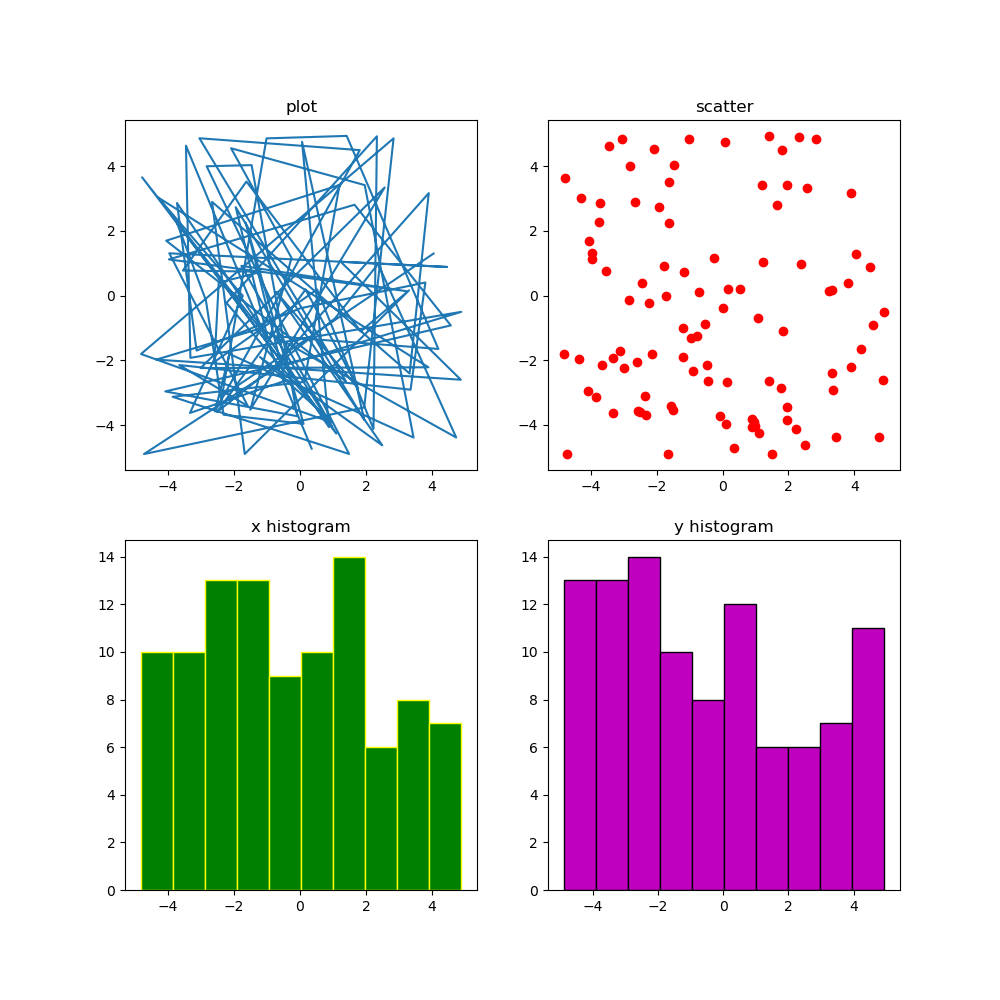

```python
import matplotlib.pyplot as plt
# Burada figür kısmı kritik bunu almamız lazım
fig, axes = plt.subplots(nrows=2, ncols=2,figsize=(10,10))

# biraz veri hazırlayalım
y = np.random.uniform(low=-5,high=5,size = 100)
x = np.random.uniform(low=-5,high=5,size = 100)

# axes iki boyutlu bir matris olarak döndürülüyor
# sol üst eksene plot çizdirelim
axes[0][0].plot(x,y)
axes[0][0].set_title("plot")

# sağ üst eksene scatter çizdirelim
axes[0][1].scatter(x,y,c='r')
axes[0][1].set_title("scatter")

# sol alt eksene x histogram, sağ alt eksene y histogram
axes[1][0].hist(x,color="g",edgecolor="yellow")
axes[1][0].set_title("x histogram")
axes[1][1].hist(y,color="m",edgecolor="k")
axes[1][1].set_title("y histogram")
```

`iplot_mpl` fonksiyonunu import ederek `matplotlib` figürlerini çizdirebiliyoruz. Tabi bunu "offline" kullanmak için `plotly.offline` modülünden çağırmamız gerekiyor.

```python
from plotly.offline import iplot_mpl

iplot_mpl(fig)
```

[interactive chart not shown]

Yani hem alıştığınız `matplotlib` ortamını kullanıp hem de `plotly`nin interaktif ortamından faydalanmak mümkün. Bir örnek daha yapalım isterseniz

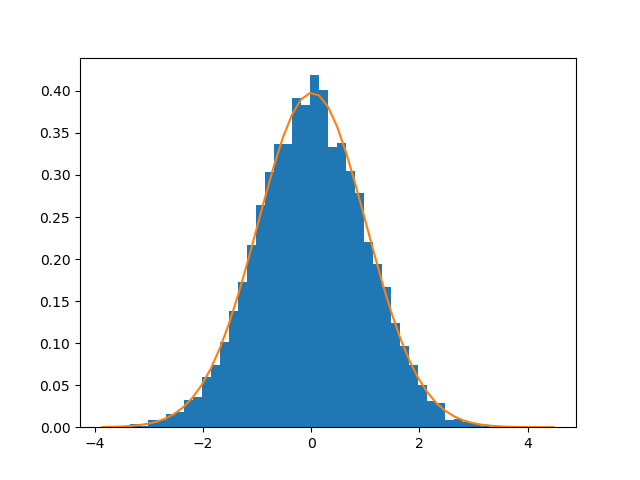

```python
import numpy as np
import scipy.stats as stats

hist_fig, ax = plt.subplots()

x = np.random.randn(10000);
# histogramı çizdirelim
n, bins, patches = plt.hist(x,density=True,bins =50)

#---------------------
# burayı çok önemsemeyim sadece çizime odaklanın :)

# bir gauss pdf çizdirelim üstüne egzersiz olsun
# ortalama ve std bulunur
m, s = stats.norm.fit(x)
# pdf değerleri hesaplanır
pdf_g = stats.norm.pdf(bins, m, s)
#---------------------

plt.plot(bins, pdf_g, label="Norm")
```

```python
iplot_mpl(hist_fig)
```

[interactive chart not shown]

## `plotly`deki egzotik grafik örnekleri

### `sunburst`

Şimdi sizlere çok şık bir grafik gösteceğim, hem de animasyonlu :) Yani grafiğin üzerine tıkladığınızda alt dağılımları görmeniz mümkün. Grafik temelde bir piechart gibi ama çok katmanlı.

Bir örnek üzerinden gidelim diyelim ki "Gelir" ve "Gider" olarak iki kaleminiz var ve bu kalemlerdeki harcamları bölerek göstermek istiyorsunuz.

Öncelikle "labels" kısmına tüm kalemleri, "parents" kısmına da bağlı oldukları ana kalemleri yazıyorsunuz. Yani örneğimizde bu kalemlerin hiyerarşisi ve bunların değerleri aşağıdaki gibi:

- Bütçe (0)
  - Gelir (0)
    - Danışmanlık (100)
    - Mühendislik (90)
    - Eğitim (60)
  - Gider
    - Malzeme (100)
    - Ulaşım (20)
    - Personel (80)

Burada dikkat etmeniz gereken bir başka husus da eğer alt kalemleri kullanarak bir üst kalemi belirlemek istiyorsanız, üst kalem için "values" kısmına 0 girmeniz gerektiği.

```python
# grafik objelerini de go şeklinde import edelim
import plotly.graph_objs as go
from plotly.offline import download_plotlyjs, init_notebook_mode, plot, iplot

trace = go.Sunburst(
    labels=["Bütçe", "Gelir", "Gider", "Malzeme", "Ulaşım", "Personel", "Danışmanlık", "Mühendislik", "Eğitim"],
    parents=["", "Bütçe", "Bütçe", "Gider", "Gider", "Gider", "Gelir", "Gelir", "Gelir" ],
    values=[0, 0, 0, 100, 20, 80, 100, 90, 60],
    outsidetextfont = {"size": 20, "color": "#377eb8"},
    marker = {"line": {"width": 2}},
)

layout = go.Layout(
    margin = go.layout.Margin(t=0, l=0, r=0, b=0)
)

iplot(go.Figure([trace], layout), filename='basic_sunburst_chart')
```

[interactive chart not shown]

### `sankey`

Bir akışı betimlemek veya birbiri ile orantılarını göstermek için `sankey` diyagramı kullanılır. Yaratıcı kullanım alanları da vardır bu grafiğin. Örneğin bir seçimde partiler arasında geçiş yapan seçmenleri analiz etmek için kullanılabilir. [Ref: cilekagaci.com](http://cilekagaci.com/2018/06/30/haziran-2018-secim-analizi-ve-oy-gecisleri/)

```python
import plotly.plotly as py

data = dict(
    type='sankey',
    node = dict(
      pad = 15,
      thickness = 20,
      line = dict(
        color = "black",
        width = 0.5
      ),
      label=["Bütçe", "Gelir", "Gider", "Malzeme", "Ulaşım", "Personel", "Danışmanlık", "Mühendislik", "Eğitim"],
      color = ["yellow", "blue", "red", "red", "red", "red","blue","blue","blue"]
    ),
    link = dict(
      source = [0,0,1,1,1,2,2,2],
      target = [1,2,6,7,8,3,4,5],
      value = [200,250,100,20,80, 100, 90, 60]
  ))




fig = dict(data=[data])
iplot(fig, validate=False)
```

[interactive chart not shown]